# Blockchain Footprint

## The question behind the headline

> Are blockchains really destroying our planet?
- The debate is often affected by **cliches, biases, misconceptions and pitfalls**
- Different blockchains do not necessarily have the same electricity consumption
- The main difference is the method used to reach consensus over the state of the system
- We must distinguish **electricity consumption** from the wider **environmental footprint**

Main claim: the word “blockchain” alone is not a sufficient unit of environmental analysis.

## Road map

1. Blockchain as part of the *Web3 ecosystem*
2. Proof of Work and block production
3. The economics of Bitcoin mining
4. How Bitcoin electricity consumption is estimated
5. Electricity consumption and environmental footprint
6. Proof of Work and Proof of Stake
7. Mitigation options and conclusions

The Web3 ecosystem is a collection of blockchain-based technologies and applications designed to let users exchange digital assets and interact with decentralized services without relying exclusively on a central intermediary.

## Blockchain state and consensus

A blockchain system must maintain an agreed state across a network of participants.

- Transactions describe proposed changes to the state
- Participants verify transactions according to common rules
- A **consensus mechanism** determines which valid history is accepted
- In a **trustless environment**, agreement does not depend on personal trust between participants

The environmental question begins with the mechanism used to secure agreement over the state of the system.

## Why consensus has an environmental cost

- The network needs a **consensus mechanism** to agree on which transactions and blocks belong to the accepted blockchain history
- In **Proof of Work**, miners create candidate blocks and compete to find a valid cryptographic result
- Finding this result requires a very large number of repeated hash calculations
- The first miner to find a valid result can broadcast the candidate block to the network
- Other participants can quickly verify the result and accept the valid block

Proof of Work uses computational effort and electricity to make block production costly and attacks economically difficult.

## Mining effort and block contents

- The **Proof-of-Work difficulty** does not depend significantly on the number of transactions included in a candidate block
- Instead, the difficulty is adjusted according to the rules of the blockchain protocol, usually in response to how quickly recent blocks were produced
- Its purpose is to keep block production close to the target rate defined by the protocol, even when the total network hashrate changes
- A block containing many transactions requires some additional validation and network communication
- However, the number of transactions does not significantly affect the probability of finding a valid **Proof-of-Work hash**
- Therefore, at the same difficulty, blocks with few or many transactions require the same expected number of hash attempts on average

Adding one more transaction does not cause a proportional increase in the blockchain’s electricity consumption.

## Market capitalisation and power demand across Proof-of-Work networks

The study analysed **20 Proof-of-Work cryptocurrencies** that collectively represented approximately **98.22% of the total market capitalisation of mineable cryptocurrencies in 2020**.

**Market capitalisation** measures the total market value of a cryptocurrency and is calculated by multiplying its market price by the number of coins in circulation:

\[ \text{Market capitalisation} = \text{price per coin} \times \text{circulating supply} \]

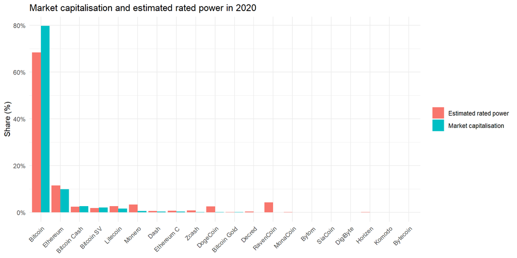

- Ethereum refers to its **pre-Merge Proof-of-Work network**

Market value and mining power are related but not proportional: a network’s share of market capitalisation does not directly determine its share of Proof-of-Work power demand.

**Data source:** Emam, R. (2023), *Cryptocurrency: An Analysis of Energy Usage*, reproducing data from Gallersdörfer, U., Klaaßen, L. and Stoll, C. (2020), *Energy Consumption of Cryptocurrencies Beyond Bitcoin*. [View the reproduced table on the Stanford University course website](http://large.stanford.edu/courses/2023/ph240/emam1/).

## Proof of Work as an economic incentive

- Miners voluntarily incur financial costs before knowing whether they will receive a reward
- Dishonest behaviour can leave the miner with sunk costs but no block reward
- If miners are profit-maximising agents, following the rules becomes the rational strategy
- Bitcoin can therefore be viewed as a **socio-economic system** combining:
  - technical rules that define valid transactions and blocks
  - economic incentives that reward accepted blocks
  - strategic competition among miners, for whom following the protocol is generally more profitable than cheating

Proof of Work promotes honesty over cheating by making dishonest behaviour economically costly.

## The costs and revenues of miners

Mining profitability depends on the relationship between **mining revenues** and **mining costs**:

- **Capital expenditures:** initial investments in mining infrastructure and **Application-Specific Integrated Circuits (ASICs)**, specialised computers designed to perform a specific Proof-of-Work algorithm
- **Operational expenditures:** recurring costs, mainly electricity, cooling, maintenance, and personnel
- **Block subsidy:** newly issued coins awarded to the miner who successfully produces an accepted block
- **Transaction fees:** payments included by users to incentivise miners to include their transactions in a block

> **Expected profit** = **block subsidy** + **transaction fees** - **capital expenditures** - **operational expenditures**

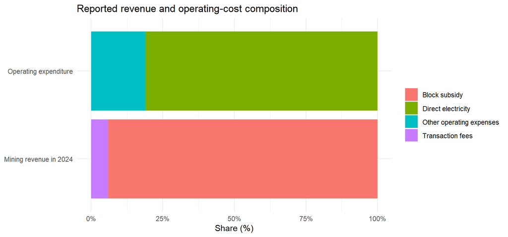

- In 2024, transaction fees represented approximately **6% of total mining rewards**, while the block subsidy provided the remaining **94%**
- In the surveyed firms, direct electricity represented **81.1% of cash operating expenditure**, while other operating expenses represented **18.9%**
- The operating-cost bar excludes capital expenditure and non-cash expenses, so it does not represent the miner’s complete lifetime cost structure

Mining revenue still depends mainly on the block subsidy, while electricity dominates recurring cash operating costs.

**Data:** Cambridge Centre for Alternative Finance (2025), *Cambridge Digital Mining Industry Report*, Figures 39 page 81-82 (“Transaction fees in 2024 still only accounted for approximately 6% of total mining rewards.”) and 44(b) page 87. [View the report](https://issuu.com/cambridgejbs/docs/cambridge_digital_mining_industry_report).

## Mining infrastructure

[figure not shown]

- Industrial mining combines specialised **Application-Specific Integrated Circuit (ASIC) hardware**, electricity supply, cooling, and network connectivity
- Location and electricity contracts strongly influence operating costs and environmental impact

**External image:** “Cryptocurrency Mining Farm”, Wikimedia Commons. [View the original image and licence information](https://commons.wikimedia.org/wiki/File:Cryptocurrency_Mining_Farm.jpg).

## The main driver: expected mining profitability

- The main driver of Proof-of-Work electricity consumption is **expected mining profitability**
- Main revenue factors:
  - market price of the mined coin
  - block reward
  - transaction fees
- Main cost factor:
  - electricity price

coin price, fees and electricity price strongly influence the energy footprint.

## Measuring mining hardware efficiency

- A **hash** is one attempt to find a valid Proof-of-Work result
- One **terahash (TH)** represents one trillion hash calculations
- Hardware efficiency is measured in **joules per terahash (J/TH)**, meaning the energy required to perform one trillion hashes
- A lower J/TH value means that the hardware performs the same computational work using less electricity

> **Example:** a device operating at **100 TH/s** with an efficiency of **25 J/TH** requires approximately **2,500 W**  
> \(100\ \text{TH/s} \times 25\ \text{J/TH} = 2{,}500\ \text{J/s} = 2{,}500\ \text{W}\)

J/TH measures the electricity required for a unit of computational work: lower values indicate more efficient hardware.

## From profitability to active hardware

Hardware efficiency affects operating costs, but whether a machine remains active also depends on:

- **Hashprice:** daily mining revenue earned for each petahash per second of computational power (**1 PH/s equals 1,000 TH/s and is used to avoid expressing revenue with very small decimal values**)
- **Electricity price:** cost of the electricity required to operate the machine

The percentage shown in each cell is the **hash margin**:

\[ \text{Hash margin} = \frac{\text{hashprice}-\text{electricity cost}} {\text{hashprice}} \times 100 \]

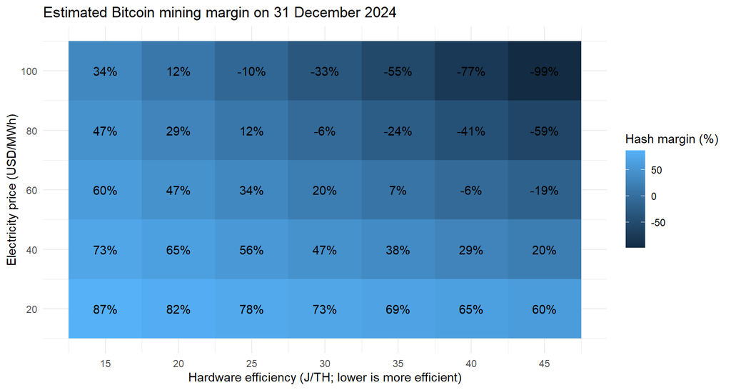

- A **positive margin** means that expected mining revenue exceeds electricity costs
- A **negative margin** means that operating the machine costs more than its expected revenue
- Higher electricity prices make less-efficient hardware unprofitable first
- A higher hashprice can allow additional hardware to operate profitably

> **Profitability decreases**  
> less-efficient machines become unprofitable  
> \(\rightarrow\) machines are switched off  
> \(\rightarrow\) network hashrate and electricity demand can decrease

> **Profitability increases**  
> additional machines become profitable  
> \(\rightarrow\) machines can be activated  
> \(\rightarrow\) network hashrate and electricity demand can increase

Hardware efficiency determines operating cost, while hashprice and electricity price determine whether operating that hardware is profitable.

**Data and methodology:** Cambridge Centre for Alternative Finance (2025), *Cambridge Digital Mining Industry Report*, Figure 50(a), p. 92. Calculations assume a Bitcoin hashprice of **$54.3/PH/day** on 31 December 2024. [View the report](https://issuu.com/cambridgejbs/docs/cambridge_digital_mining_industry_report").

## Hashrate can grow faster than electricity consumption

From the beginning of 2021 to the end of 2024, Bitcoin’s computational power and electricity consumption both increased, but not at the same rate.

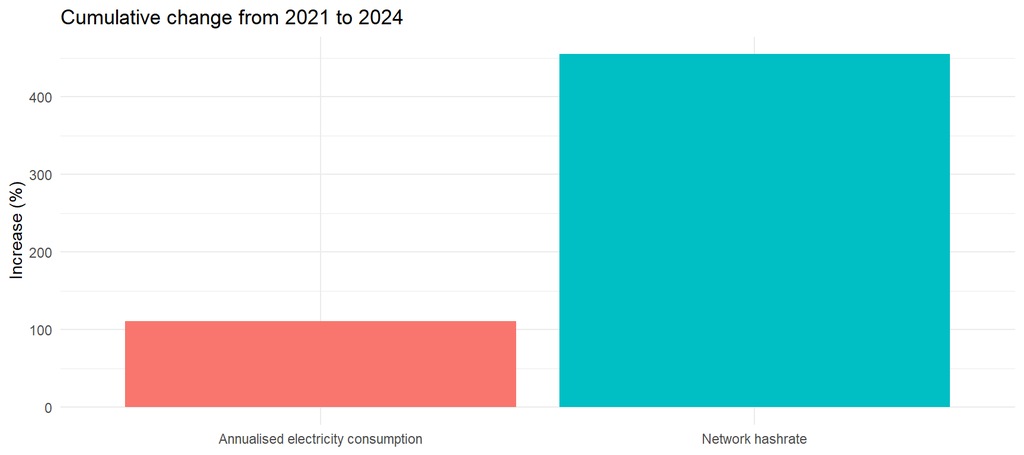

- Bitcoin’s network hashrate increased by approximately **455%**
- Annualised electricity consumption increased by approximately **111%**
- Estimated hardware efficiency improved from slightly above **60 J/TH** to approximately **23.7 J/TH**

Efficiency improvements reduced electricity per hash, so computational power increased much faster than total electricity consumption.

**Data:** Cambridge Centre for Alternative Finance (2025), *Cambridge Digital Mining Industry Report*, Figure 27 page 61, and Figure 28 page 62 (“Efficiency at the beginning of the observed period […] stood slightly above 60 J/TH […] before gradually improving to 23.7 J/TH by the end of 2024.”, “The implied network hashrate […] surged by 455% from 143 EH/s to 796 EH/s over the same period.”). [View the report](https://issuu.com/cambridgejbs/docs/cambridge_digital_mining_industry_report)

## How CBECI estimates electricity consumption

The **Cambridge Bitcoin Electricity Consumption Index (CBECI)** is maintained by the Cambridge Digital Assets Programme at the Cambridge Centre for Alternative Finance.

The complete hardware operating across the Bitcoin network cannot be observed directly. CBECI therefore estimates electricity consumption by combining:

- the observable network **hashrate**
- a database of mining devices and their efficiencies
- mining revenue and an assumed electricity price
- the profitability mechanism introduced in the previous slide

The model produces three scenarios:

- **Theoretical lower bound:** assumes that all mining uses the most efficient available hardware
- **Best estimate:** assumes a plausible combination of profitable mining devices
- **Theoretical upper bound:** assumes the least-efficient hardware that could still operate profitably

The estimated hardware mix is used to convert network hashrate into power demand and annualised electricity consumption.

CBECI applies the profitability mechanism to estimate which hardware may be active and how much electricity that hardware requires.

**Methodology:** Cambridge Centre for Alternative Finance, *Cambridge Bitcoin Electricity Consumption Index*. The model combines network hashrate, mining revenue, electricity-price assumptions, and a basket of real mining hardware to produce lower-bound, best-estimate, and upper-bound scenarios. [View the CBECI methodology](https://ccaf.io/cbnsi/cbeci/methodology).

## Survey-based calculation: a real example

The 2025 Cambridge Digital Mining Industry Report provides an independent calculation based on operational data reported directly by mining firms.

Researchers surveyed **49 mining firms** active in **23 countries**, together representing approximately **48% of the global Bitcoin hashrate**.

The firms reported the efficiency of their operational hardware. Each response was weighted by the firm’s reported hashrate, so larger mining operations had more influence on the resulting estimate.

> **Data for 30 June 2024**  
> Network hashrate: **558.7 EH/s** = **558.7 million TH/s**  
> Hashrate-weighted hardware efficiency: **28.2 J/TH**

> **Estimated power demand**  
> \(558.7\) million TH/s \(\times 28.2\) J/TH  
> \(= 15.8\) billion J/s \(\approx\) **15.8 GW**

> **Annualised electricity consumption**  
> \(15.8\) GW \(\times 8{,}760\) hours/year  
> \(\approx\) **138.2 TWh/year**

**Annualised consumption** is the electricity that would be consumed if the estimated power demand remained constant for one complete year. It is a projection based on the estimated power rate, not necessarily electricity already consumed during the calendar year.

The survey provides an independent estimate based on reported hardware efficiency, rather than inferring the active hardware mix through profitability assumptions.

**Data and methodology:** Cambridge Centre for Alternative Finance (2025), *Cambridge Digital Mining Industry Report*, Figure 26(a), p. 60, and Figure 29, p. 63. Figure 26(a) reports a hashrate-weighted ASIC efficiency of **28.2 J/TH** as of 30 June 2024. Figure 29 combines this efficiency with an implied network hashrate of **558.7 EH/s**, producing a survey-based estimate of **138.2 TWh/year**. [View the report](https://issuu.com/cambridgejbs/docs/cambridge_digital_mining_industry_report).

## Environmental scale of Bitcoin mining

The survey-based calculation and the separate CBECI model produced similar electricity estimates for the same period:

- **Survey-based estimate:** 138.2 TWh/year
- **CBECI model estimate:** 137.4 TWh/year

The similarity provides a useful cross-check because the two methods estimate the mining hardware differently.

The report placed the survey-based result in a broader environmental context:

- approximately **0.54% of global annual electricity consumption**
- approximately **39.8 MtCO2e/year** of greenhouse-gas emissions

Electricity consumption measures the amount of electrical energy used. Greenhouse-gas emissions also depend on the **carbon intensity of the energy sources** supplying mining operations.

The two methods agree on the approximate scale of electricity consumption, but the environmental impact also depends on how that electricity is generated.

**Data and methodology:** Cambridge Centre for Alternative Finance (2025), *Cambridge Digital Mining Industry Report*, Figure 29, page 63, and Figure 32, page 69. The report states that the survey-based estimate of **138.2 TWh/year** as of 30 June 2024 represented approximately **0.54% of global annual electricity consumption** and closely aligned with the separate CBECI estimate of **137.4 TWh/year**. Figure 32 reports a survey-based emission intensity of **288.2 gCO2e/kWh**, which corresponds to approximately **39.8 MtCO2e/year** when applied to the estimated electricity consumption. [View the report](https://issuu.com/cambridgejbs/docs/cambridge_digital_mining_industry_report).

## Reported Bitcoin mining energy mix

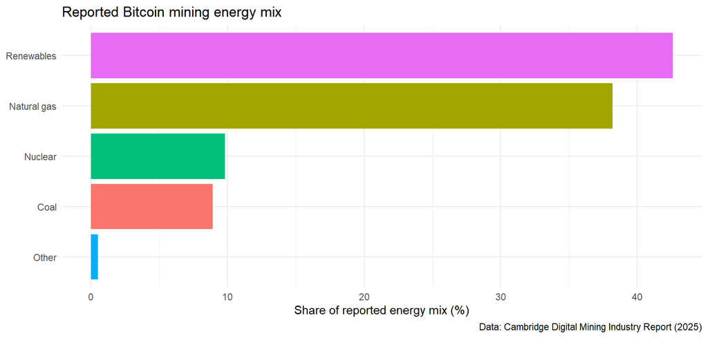

- Renewables and nuclear together represent the reported **52.4% sustainable-energy share**
- The energy mix refers to the report’s sample and period, not a permanent global value

**Data and methodology:** Cambridge Centre for Alternative Finance (2025), *Cambridge Digital Mining Industry Report*, Figure 31(a), page 67. Based on survey responses weighted by participants’ reported power consumption, the report estimates that the electricity mix as of 30 June 2024 consisted of **42.6% renewables**, **38.2% natural gas**, **9.8% nuclear**, **8.9% coal**, and **0.5% oil**. Renewables and nuclear together form the reported **52.4% sustainable-energy share**.[View the report](https://issuu.com/cambridgejbs/docs/cambridge_digital_mining_industry_report).

## Electricity consumption is not environmental footprint

> What ultimately matters for the environment is not electricity consumption per se, but the carbon intensity of the energy sources used to generate it.

\[\text{GHG emissions}=\sum_i \text{electricity}_i\times\text{carbon intensity}_i\]

- The **carbon intensity** of an energy source is the amount of greenhouse-gas emissions produced for each unit of electricity generated
- Electricity generated from coal generally has a higher carbon intensity than electricity generated from wind, solar, or hydroelectric power
- Two mining operations can consume the same amount of electricity but produce different emissions if their energy sources are different
- Carbon intensity can also vary according to the location, time of day, season, and electricity available on the grid

Electricity consumption indicates how much energy is used; carbon intensity determines how strongly that energy use contributes to climate change.

## Miners as “energy nomads”

Mining operations require specialised hardware, electricity, cooling, and an internet connection, but they do not need to be located close to their users.

- Mining facilities can move to regions where electricity is cheaper or more readily available
- This geographical flexibility is why miners are sometimes described as **energy nomads**
- Some facilities may use **curtailed electricity**, meaning electricity that could be generated but cannot be used or transmitted at that time
- One example is surplus hydroelectric generation during periods of heavy rainfall
- Some facilities use natural gas that would otherwise be burned through **gas flaring** at oil-production sites

However, using surplus or flared energy does not automatically create an environmental benefit. The relevant question is what would have happened to that energy without the mining operation.

The environmental effect of mining depends on the local energy system and on the realistic alternative use of the electricity.

## The environmental footprint extends beyond carbon

An **environmental footprint** measures the different pressures that an activity places on natural resources, ecosystems, and local communities.

- **Carbon footprint:** greenhouse-gas emissions associated with electricity generation, infrastructure, and supply chains
- **Water footprint:** water used directly for cooling or indirectly by the facilities that generate electricity
- **Land footprint:** land occupied by power-generation infrastructure, transmission networks, and mining facilities
- **Material footprint:** raw materials and energy required to manufacture mining hardware and infrastructure
- **Electronic waste:** mining devices that are discarded when they fail or become technically or economically obsolete
- **Local effects:** noise, waste heat, grid congestion, and possible changes in local electricity demand and prices

A complete assessment must consider resource use, hardware, and local effects in addition to electricity consumption and greenhouse-gas emissions.

## What does Bitcoin’s wider footprint mean?

A 2023 global assessment by researchers associated with the **United Nations University Institute for Water, Environment and Health (UNU-INWEH)** examined Bitcoin mining activities across **76 countries** during the **2020-2021 period**.

The study estimated:

- **173.42 TWh of electricity consumption** during 2020-2021, reported by the study as greater than the electricity consumption of most individual countries
- **85.89 MtCO2e of greenhouse-gas emissions**, comparable to the annual emissions of approximately **190 natural-gas power plants**
- **1.65 km³ of water footprint**, equivalent to approximately **1.65 trillion litres** or **660,000 Olympic-sized swimming pools**
- more than **1,870 km² of land footprint**, approximately **1.4 times the area of Los Angeles**

### Calculations behind the comparisons

> **Water volume**  
> \(1\ \text{km}^3 = 10^{12}\ \text{litres}\)  
> \(1.65\ \text{km}^3 = 1.65 \times 10^{12} = 1.65\ \text{trillion litres}\)

> **Olympic-sized swimming pools**  
> Using a reference pool of \(50\ \text{m} \times 25\ \text{m} \times 2\ \text{m}\):  
> \(50 \times 25 \times 2 = 2{,}500\ \text{m}^3\)  
> \(2{,}500\ \text{m}^3 \times 1{,}000 = 2.5 \times 10^6\ \text{litres per pool}\)  
> \(\dfrac{1.65 \times 10^{12}\ \text{litres}}{2.5 \times 10^6\ \text{litres per pool}} = 660{,}000\ \text{pools}\)

> **Natural-gas power plants**  
> The study compares 85.89 MtCO2e with approximately 190 plants:  
> \(\dfrac{85.89\ \text{MtCO2e}}{190} \approx 0.452\ \text{MtCO2e per plant}\)  
> \(190 \times 0.452 \approx 85.9\ \text{MtCO2e}\)

> **Land area**  
> The study reports that 1,870 km² is approximately 1.4 times the area of Los Angeles:  
> \(\dfrac{1{,}870\ \text{km}^2}{1.4} \approx 1{,}336\ \text{km}^2\)

The **water footprint** includes water associated with electricity generation and cooling. The **land footprint** includes land connected to the energy sources and infrastructure supporting mining.

The country-level electricity comparison is contextual information reported by the study. It is not derived from 173.42 TWh alone and requires a separate dataset of national electricity consumption.

The study shows that Bitcoin mining affects not only electricity consumption and climate, but also water and land resources.

**External source:** Chamanara, S., Ghaffarizadeh, S. A., Madani, K. and Dascalu, S. (2023), *The Environmental Footprint of Bitcoin Mining Across the Globe: Call for Urgent Action*, *Earth’s Future*, 11(10). [View the study](https://collections.unu.edu/view/UNU:9800).

## Why “energy per transaction” can be misleading

A common metric divides the network’s total electricity consumption by the number of recorded transactions:

\[ \text{energy per transaction} = \frac{\text{total network electricity}}{\text{number of on-chain transactions}} \]

However, this calculation does not measure the additional electricity required to process one more transaction.

- Miners perform Proof of Work to produce blocks, whether those blocks contain few or many transactions
- Adding one transaction to a candidate block does not cause miners to perform a proportional amount of additional hashing
- The resulting value only distributes the network’s total electricity across the recorded transactions
- One on-chain transaction may also represent several payments grouped together by an exchange or another service

“Energy per transaction” is an average allocation of network electricity, not the electricity directly caused by one individual transaction.

## Ethereum before and after The Merge

Ethereum completed **The Merge** on **15 September 2022**, replacing Proof of Work with Proof of Stake.

- Before The Merge, miners competed to produce blocks through repeated hash calculations
- After The Merge, validators lock ETH as **stake**, meaning capital that can be penalised if they violate the protocol
- Producing blocks no longer requires competitive mining

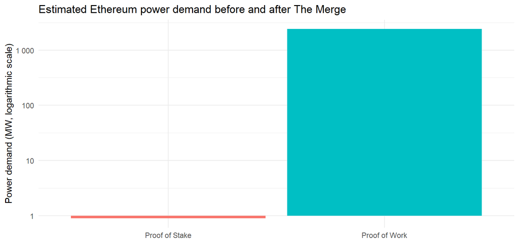

- Final pre-Merge demand was approximately **2.4 GW**, or **2,400 MW**
- The updated post-Merge estimate is approximately **0.90 MW**, equivalent to **7.87 GWh/year**
- The reduction remains greater than **99.9%**

The Merge removed competitive mining and reduced Ethereum’s operational electricity demand by more than three orders of magnitude.

**Data:** Cambridge Centre for Alternative Finance (2026), *Ethereum After the Merge – A Change in Power*. The vertical axis uses a logarithmic scale. [View the report](https://www.jbs.cam.ac.uk/faculty-research/centres/alternative-finance/publications/ethereum-after-the-merge-a-change-in-power/).

## How Cambridge estimates post-Merge Ethereum

Post-Merge Ethereum is evaluated using a node-based method rather than Bitcoin’s mining-hardware and profitability model.

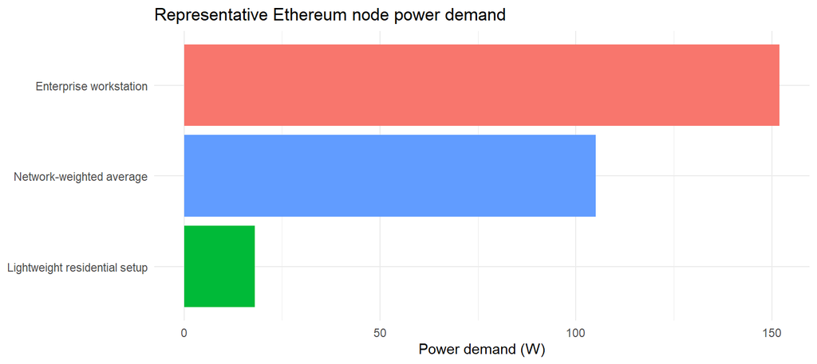

The Cambridge analysis:

- identifies approximately **8,522 physical nodes**, which are distinct from the much larger number of economic validators
- tests the wall-plug power demand of **20 client combinations**
- scales representative hardware measurements using real-world hosting and network-composition data
- converts estimated node power into annualised electricity consumption

Bitcoin estimates focus on profitable mining hardware; post-Merge Ethereum estimates focus on the number, type, and power demand of network nodes.

**Data:** Cambridge Centre for Alternative Finance (2026), *Ethereum After the Merge – A Change in Power*. Values represent reported medians or network-weighted estimates for the hardware profiles used in the study. [View the methodology](https://ccaf.io/cbnsi/ethereum/methodology).

## Proof of Work and Proof of Stake

### Proof of Work

- **Participants:** miners
- **Resource used for consensus:** computational work, specialised hardware, and electricity
- **Economic risk:** electricity and hardware costs are paid even when a miner does not receive the block reward
- **Environmental effects:** electricity consumption, greenhouse-gas emissions, cooling requirements, and electronic waste

### Proof of Stake

- **Participants:** validators
- **Resource used for consensus:** staked cryptocurrency rather than competitive mining
- **Economic risk:** dishonest validators may lose part of their stake through **slashing**
- **Environmental effects:** electricity used by validator servers and network infrastructure, but at a much lower scale than competitive Proof-of-Work mining

Proof of Stake greatly reduces operational electricity demand, but it introduces different questions concerning the concentration of stake, reliance on hosting providers, and protocol governance.

Proof of Work secures consensus through costly computation, while Proof of Stake secures consensus by placing validators’ capital at risk.

## Can mining support cleaner energy systems?

Mining facilities can change their electricity demand rapidly and can operate close to energy sources rather than close to blockchain users.

### Possible benefits

- Mining facilities may temporarily reduce their electricity use when the grid is under stress, a practice known as **demand response**
- Mining may use **curtailed electricity**, meaning electricity that could be generated but cannot currently be used or transmitted
- Facilities may operate near remote energy sources that are not conveniently connected to other consumers
- Some projects use natural gas that would otherwise be burned through **gas flaring**

### Important limitations

- The **counterfactual** must be considered: what would realistically happen to the energy if mining were absent?
- Electricity described as surplus today might be stored, transmitted, or used by another consumer in the future
- Burning flared gas still produces carbon dioxide, while methane leakage can add a powerful greenhouse-gas effect
- A renewable-electricity contract does not prove that mining caused new renewable generation to be built
- Noise, waste heat, water use, grid pressure, and community effects remain specific to each location

Mining can support an energy system only when the claimed benefit is demonstrated using local data and a credible alternative scenario.

## A hierarchy for reducing the footprint

Environmental measures should be considered in a logical order:

1. **Avoid:** use a low-energy consensus mechanism when Proof of Work is not required
2. **Reduce:** improve hardware efficiency, cooling systems, and facility operations
3. **Shift:** replace carbon-intensive electricity with genuinely low-carbon generation
4. **Integrate:** provide verifiable demand response or use electricity that would otherwise be curtailed
5. **Extend:** increase hardware lifetime through maintenance, reuse, resale, and refurbishment
6. **Recycle:** recover useful materials from equipment that can no longer be reused
7. **Measure and govern:** disclose energy sources, hardware, locations, emissions, uncertainty, and local environmental effects

More efficient hardware reduces electricity consumption per hash, but it does not guarantee a proportional reduction in total network consumption. Lower operating costs can improve profitability and encourage additional mining activity.

Changing the consensus mechanism offers the largest possible reduction; efficiency and cleaner electricity reduce the footprint of systems that continue to use Proof of Work.

## Questions to ask when evaluating an estimate

Before comparing environmental estimates, a data scientist should identify exactly what each number represents.

- **Measured quantity:** is the value power demand, annualised consumption, observed consumption, emissions, or a wider environmental footprint?
- **Method:** is the estimate based on direct measurements, an industry survey, a hardware model, or economic assumptions?
- **Hardware assumptions:** which mining devices or validator computers are assumed to be active?
- **System boundary:** does the estimate include only computing equipment, or also cooling, buildings, transmission losses, manufacturing, and disposal?
- **Time and location:** which period, countries, and electricity sources are represented?
- **Emission factors:** are emissions based on an annual average electricity mix or on the generation sources responding at a particular time?
- **Uncertainty:** are lower and upper bounds or sensitivity analyses provided?
- **Comparison:** do the values use equivalent periods, units, boundaries, and services?

The difficult part is not producing a number, but defining what the number includes and whether it can be compared fairly with another estimate.

## Conclusions

- The environmental footprint of a blockchain depends strongly on its **consensus mechanism**
- Proof-of-Work electricity is used mainly for the competition to produce valid blocks, not for processing each transaction individually
- The number and efficiency of active mining machines depend partly on **expected mining profitability**
- Bitcoin electricity consumption cannot be measured directly for the entire network and must therefore be estimated using surveys or models
- Electricity consumption and greenhouse-gas emissions are different quantities because emissions depend on the **carbon intensity** of the energy supply
- A complete environmental assessment may also include water, land, materials, electronic waste, and local effects
- Ethereum demonstrates that replacing Proof of Work with Proof of Stake can reduce electricity demand by orders of magnitude

> The relevant question is not simply **“Is blockchain sustainable?”**, but **“Which blockchain, secured by which consensus mechanism, powered where, measured during which period, and compared with what?”**